# Reproducable Research: Programming Assignment 1

```r
library(dplyr)
```

```r
library(ggplot2)
library(lattice)
```

## Loading and preprocessing the data

With the following codechunk the working directory is set and the variable “activity” is created, which contains the data. In the final step, all NA values are removed.

```r
# set working directory
setwd("D:/Projects/R/Coursera/Week 4/data2/")

# create variable activity
data <- read.csv("activity.csv")

# remove all NA in the variable activity
activity <- data[ with (data, { !(is.na(steps)) } ), ]
```

## What is mean total number of steps taken per day?

Creating a histogram with the total Number of steps by day.

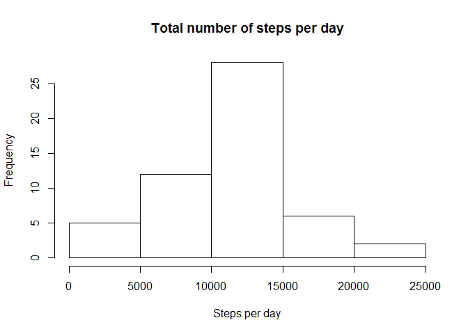

```r
# aggregate steps by date
steps <- aggregate(activity$steps, by=list(date=activity$date), FUN=sum)

# histogram of Number of steps by day
hist(steps$x, main = "Total number of steps per day", xlab = "Steps per day")
```

The mean of the total steps per day is 10766.19, the median is 10765.

```r
# mean of total number of steps
mean(steps$x)
```

```
## [1] 10766.19
```

```r
# median of total number of steps
median(steps$x)
```

```
## [1] 10765
```

## What is the average daily activity pattern?

Creating a time series plot with the average number of steps of all days.

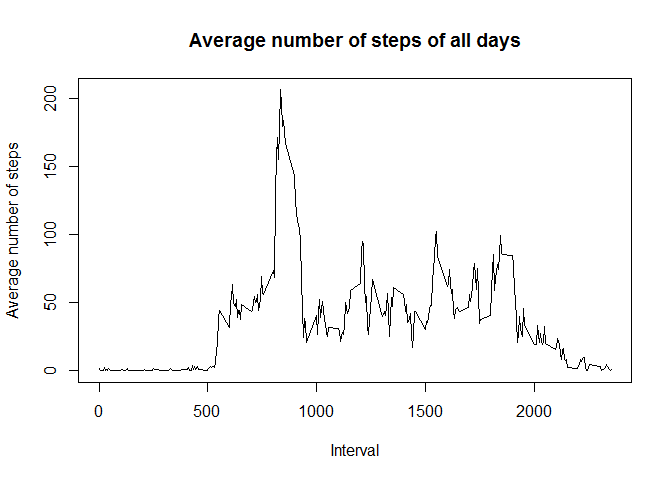

```r
# create variable steps_interval
steps_interval <- aggregate(activity$steps, by=list(interval=activity$interval), FUN=mean)


# create time series plot
plot(steps_interval$interval, steps_interval$x, type='l',
     main="Average number of steps of all days", xlab="Interval",
     ylab="Average number of steps")
```

The interval 835 contains the highest average of steps with around 206.2.

```r
steps_interval %>% filter(steps_interval$x == max(steps_interval$x))
```

```
##   interval        x
## 1      835 206.1698
```